# Advanced R Programming

Aug, 14, 2019

## What we do?

- Some methods to improve control flow and function creation
- Idea of how the R language works
- Reviews of objects, data types, and control flow including the role of **scope** and **environments**
1. R’s approach to **OOP (Object-Oriented Programming)** and the creation of **generic functions**
2. Tips for writing efficient code-generating and debugging applications

## A review of the language

`R` is an  
1. object-oriented,  
2. functional,  
3. array programming  
language in which objects are specialized data structures, stored in RAM, and accessed via names or symbols.

Names of objects consist of

- uppercase and lowercase letters,
- the digits 0–9,
- the period,

and the underscore. Names are **case-sensitive** and can’t start with a digit, and a period is treated as a simple character without special meaning.

1. attributes : meta-information describing the characteristics of the object.
- Attributes can be listed with `attributes()` and set with the `attr()`
- A key attribute is an object’s `class`

`class()` can read the class of an object. A class determines the way an object is handled.

## OOP (Wiki)

Object-oriented programming (OOP) is a programming paradigm based on the concept of “objects”.

Examples of OOP languages : `R`, `Python`

```r
# R Objects
a <- c(1,3,2)
b <- c('s','t','r','i','n','g')
a;b
```

```
~ [1] 1 3 2
```

```
~ [1] "s" "t" "r" "i" "n" "g"
```

In OOP, computer programs are designed by making them out of objects that interact with one another.  
The most popular OOP is a **class-based** : objects are **instances** of classes, which also determine their types.

[figure not shown]

```r
class(a)
```

```
~ [1] "numeric"
```

```r
class(b)
```

```
~ [1] "character"
```

Languages that support object-oriented programming(OOP) typically use **inheritance** for code reuse and **extensibility** in the form of either classes or prototypes. Those that use classes support two main concepts:

1. Classes – the definitions for the **data format** and available procedures for a given type or class of object; may also contain data and procedures (known as class methods) themselves, i.e. classes contain the data members and member functions
2. Objects – instances of classes
- A python example with **class** and **inheritance**

```python
class Base(object):
    def __init__(self, n): # constructors
        self.n = n
        print("Parent class is Base")
        print("Can also save name : " + n)
    def ParentMethod(self) :
        print('Child can inherit parental methods!')

class Child(Base):
    def __init__(self, n):
        super(Child, self).__init__(n)

Child('Charlie').ParentMethod()
```

```
Out[]: Parent class is Base
Out[]: Can also save name : Charlie
Out[]: Child can inherit parental methods!
```

R has two OOP models : S3 and S4 models.

## Data types

### Atomic vectors

Atomic vector contains a **single** data type (logical, real, complex, character, or raw).

```r
passed <- c(TRUE, TRUE, FALSE, TRUE)
ages <- c(15, 18, 25, 14, 19)
cmplxNums <- c(1+2i, 0+1i, 39+3i, 12+2i)
names <- c("Bob", "Ted", "Carol", "Alice")
```

### Matrix

Matrix is an atomic vector that has a dimension attribute, `dim`, containing two elements.

```r
x <- c(1,2,3,4,5,6,7,8)
class(x)
```

```
~ [1] "numeric"
```

```r
print(x)
```

```
~ [1] 1 2 3 4 5 6 7 8
```

```r
attr(x, "dim") <- c(2,4)
print(x)
```

```
~      [,1] [,2] [,3] [,4]
~ [1,]    1    3    5    7
~ [2,]    2    4    6    8
```

```r
class(x)
```

```
~ [1] "matrix"
```

```r
attributes(x)
```

```
~ $dim
~ [1] 2 4
```

```r
attr(x, "dimnames") <- list(c("A1", "A2"),
                            c("B1", "B2", "B3", "B4"))
print(x)
```

```
~    B1 B2 B3 B4
~ A1  1  3  5  7
~ A2  2  4  6  8
```

```r
attr(x, "dim") <- NULL
class(x)
```

```
~ [1] "numeric"
```

```r
print(x)
```

```
~ [1] 1 2 3 4 5 6 7 8
```

### Generic vectors (lists)

Lists are collections of atomic vectors and/or other lists. **Data frames** are a special type of list, where each atomic vector in the collection has the same length.

```r
head(iris)
```

```
~   Sepal.Length Sepal.Width Petal.Length Petal.Width Species
~ 1          5.1         3.5          1.4         0.2  setosa
~ 2          4.9         3.0          1.4         0.2  setosa
~ 3          4.7         3.2          1.3         0.2  setosa
~ 4          4.6         3.1          1.5         0.2  setosa
~ 5          5.0         3.6          1.4         0.2  setosa
~ 6          5.4         3.9          1.7         0.4  setosa
```

```r
unclass(iris)
```

```
~ $Sepal.Length
~   [1] 5.1 4.9 4.7 4.6 5.0 5.4 4.6 5.0 4.4 4.9 5.4 4.8 4.8 4.3 5.8 5.7 5.4
~  [18] 5.1 5.7 5.1 5.4 5.1 4.6 5.1 4.8 5.0 5.0 5.2 5.2 4.7 4.8 5.4 5.2 5.5
~  [35] 4.9 5.0 5.5 4.9 4.4 5.1 5.0 4.5 4.4 5.0 5.1 4.8 5.1 4.6 5.3 5.0 7.0
~  [52] 6.4 6.9 5.5 6.5 5.7 6.3 4.9 6.6 5.2 5.0 5.9 6.0 6.1 5.6 6.7 5.6 5.8
~  [69] 6.2 5.6 5.9 6.1 6.3 6.1 6.4 6.6 6.8 6.7 6.0 5.7 5.5 5.5 5.8 6.0 5.4
~  [86] 6.0 6.7 6.3 5.6 5.5 5.5 6.1 5.8 5.0 5.6 5.7 5.7 6.2 5.1 5.7 6.3 5.8
~ [103] 7.1 6.3 6.5 7.6 4.9 7.3 6.7 7.2 6.5 6.4 6.8 5.7 5.8 6.4 6.5 7.7 7.7
~ [120] 6.0 6.9 5.6 7.7 6.3 6.7 7.2 6.2 6.1 6.4 7.2 7.4 7.9 6.4 6.3 6.1 7.7
~ [137] 6.3 6.4 6.0 6.9 6.7 6.9 5.8 6.8 6.7 6.7 6.3 6.5 6.2 5.9
~
~ $Sepal.Width
~   [1] 3.5 3.0 3.2 3.1 3.6 3.9 3.4 3.4 2.9 3.1 3.7 3.4 3.0 3.0 4.0 4.4 3.9
~  [18] 3.5 3.8 3.8 3.4 3.7 3.6 3.3 3.4 3.0 3.4 3.5 3.4 3.2 3.1 3.4 4.1 4.2
~  [35] 3.1 3.2 3.5 3.6 3.0 3.4 3.5 2.3 3.2 3.5 3.8 3.0 3.8 3.2 3.7 3.3 3.2
~  [52] 3.2 3.1 2.3 2.8 2.8 3.3 2.4 2.9 2.7 2.0 3.0 2.2 2.9 2.9 3.1 3.0 2.7
~  [69] 2.2 2.5 3.2 2.8 2.5 2.8 2.9 3.0 2.8 3.0 2.9 2.6 2.4 2.4 2.7 2.7 3.0
~  [86] 3.4 3.1 2.3 3.0 2.5 2.6 3.0 2.6 2.3 2.7 3.0 2.9 2.9 2.5 2.8 3.3 2.7
~ [103] 3.0 2.9 3.0 3.0 2.5 2.9 2.5 3.6 3.2 2.7 3.0 2.5 2.8 3.2 3.0 3.8 2.6
~ [120] 2.2 3.2 2.8 2.8 2.7 3.3 3.2 2.8 3.0 2.8 3.0 2.8 3.8 2.8 2.8 2.6 3.0
~ [137] 3.4 3.1 3.0 3.1 3.1 3.1 2.7 3.2 3.3 3.0 2.5 3.0 3.4 3.0
~
~ $Petal.Length
~   [1] 1.4 1.4 1.3 1.5 1.4 1.7 1.4 1.5 1.4 1.5 1.5 1.6 1.4 1.1 1.2 1.5 1.3
~  [18] 1.4 1.7 1.5 1.7 1.5 1.0 1.7 1.9 1.6 1.6 1.5 1.4 1.6 1.6 1.5 1.5 1.4
~  [35] 1.5 1.2 1.3 1.4 1.3 1.5 1.3 1.3 1.3 1.6 1.9 1.4 1.6 1.4 1.5 1.4 4.7
~  [52] 4.5 4.9 4.0 4.6 4.5 4.7 3.3 4.6 3.9 3.5 4.2 4.0 4.7 3.6 4.4 4.5 4.1
~  [69] 4.5 3.9 4.8 4.0 4.9 4.7 4.3 4.4 4.8 5.0 4.5 3.5 3.8 3.7 3.9 5.1 4.5
~  [86] 4.5 4.7 4.4 4.1 4.0 4.4 4.6 4.0 3.3 4.2 4.2 4.2 4.3 3.0 4.1 6.0 5.1
~ [103] 5.9 5.6 5.8 6.6 4.5 6.3 5.8 6.1 5.1 5.3 5.5 5.0 5.1 5.3 5.5 6.7 6.9
~ [120] 5.0 5.7 4.9 6.7 4.9 5.7 6.0 4.8 4.9 5.6 5.8 6.1 6.4 5.6 5.1 5.6 6.1
~ [137] 5.6 5.5 4.8 5.4 5.6 5.1 5.1 5.9 5.7 5.2 5.0 5.2 5.4 5.1
~
~ $Petal.Width
~   [1] 0.2 0.2 0.2 0.2 0.2 0.4 0.3 0.2 0.2 0.1 0.2 0.2 0.1 0.1 0.2 0.4 0.4
~  [18] 0.3 0.3 0.3 0.2 0.4 0.2 0.5 0.2 0.2 0.4 0.2 0.2 0.2 0.2 0.4 0.1 0.2
~  [35] 0.2 0.2 0.2 0.1 0.2 0.2 0.3 0.3 0.2 0.6 0.4 0.3 0.2 0.2 0.2 0.2 1.4
~  [52] 1.5 1.5 1.3 1.5 1.3 1.6 1.0 1.3 1.4 1.0 1.5 1.0 1.4 1.3 1.4 1.5 1.0
~  [69] 1.5 1.1 1.8 1.3 1.5 1.2 1.3 1.4 1.4 1.7 1.5 1.0 1.1 1.0 1.2 1.6 1.5
~  [86] 1.6 1.5 1.3 1.3 1.3 1.2 1.4 1.2 1.0 1.3 1.2 1.3 1.3 1.1 1.3 2.5 1.9
```

[output cut: 27 more lines]

```
~ [133] virginica  virginica  virginica  virginica  virginica  virginica
~ [139] virginica  virginica  virginica  virginica  virginica  virginica
~ [145] virginica  virginica  virginica  virginica  virginica  virginica
~ Levels: setosa versicolor virginica
~
~ attr(,"row.names")
~   [1]   1   2   3   4   5   6   7   8   9  10  11  12  13  14  15  16  17
~  [18]  18  19  20  21  22  23  24  25  26  27  28  29  30  31  32  33  34
~  [35]  35  36  37  38  39  40  41  42  43  44  45  46  47  48  49  50  51
~  [52]  52  53  54  55  56  57  58  59  60  61  62  63  64  65  66  67  68
~  [69]  69  70  71  72  73  74  75  76  77  78  79  80  81  82  83  84  85
~  [86]  86  87  88  89  90  91  92  93  94  95  96  97  98  99 100 101 102
~ [103] 103 104 105 106 107 108 109 110 111 112 113 114 115 116 117 118 119
~ [120] 120 121 122 123 124 125 126 127 128 129 130 131 132 133 134 135 136
~ [137] 137 138 139 140 141 142 143 144 145 146 147 148 149 150
```

```r
attributes(iris)
```

```
~ $names
~ [1] "Sepal.Length" "Sepal.Width"  "Petal.Length" "Petal.Width"
~ [5] "Species"
~
~ $class
~ [1] "data.frame"
~
~ $row.names
~   [1]   1   2   3   4   5   6   7   8   9  10  11  12  13  14  15  16  17
~  [18]  18  19  20  21  22  23  24  25  26  27  28  29  30  31  32  33  34
~  [35]  35  36  37  38  39  40  41  42  43  44  45  46  47  48  49  50  51
~  [52]  52  53  54  55  56  57  58  59  60  61  62  63  64  65  66  67  68
~  [69]  69  70  71  72  73  74  75  76  77  78  79  80  81  82  83  84  85
~  [86]  86  87  88  89  90  91  92  93  94  95  96  97  98  99 100 101 102
~ [103] 103 104 105 106 107 108 109 110 111 112 113 114 115 116 117 118 119
~ [120] 120 121 122 123 124 125 126 127 128 129 130 131 132 133 134 135 136
~ [137] 137 138 139 140 141 142 143 144 145 146 147 148 149 150
```

## Fitted model object

### K-means Clustering

Given a set of observations \((\mathbf{x}_1, \mathbf{x}_2, \cdots, \mathbf{x}_n)\), where each observation is a \(d\)-dimensional real vector, k-means clustering aims to partition the \(n\) observations into \(k\,(\leq n)\) sets \(S = \{S_1, S_2, \cdots, S_k\}\) so as to minimize the within-cluster sum of squares (WCSS) (i.e. variance). Formally, the objective is to find: \[{\displaystyle {\underset {\mathbf {S} }{\operatorname {arg\,min} }}\sum _{i=1}^{k}\sum _{\mathbf {x} \in S_{i}}\left\|\mathbf {x} -{\boldsymbol {\mu }}_{i}\right\|^{2}={\underset {\mathbf {S} }{\operatorname {arg\,min} }}\sum _{i=1}^{k}|S_{i}|\operatorname {Var} S_{i}}\]

### Convergence of k-means

Illustration :

[figure not shown]

### Fit kmeans on iris data

```r
set.seed(1234)
fit <- kmeans(iris[1:4], 3)
names(fit)
```

```
~ [1] "cluster"      "centers"      "totss"        "withinss"
~ [5] "tot.withinss" "betweenss"    "size"         "iter"
~ [9] "ifault"
```

```r
unclass(fit)
```

```
~ $cluster
~   [1] 1 1 1 1 1 1 1 1 1 1 1 1 1 1 1 1 1 1 1 1 1 1 1 1 1 1 1 1 1 1 1 1 1 1 1
~  [36] 1 1 1 1 1 1 1 1 1 1 1 1 1 1 1 2 2 3 2 2 2 2 2 2 2 2 2 2 2 2 2 2 2 2 2
~  [71] 2 2 2 2 2 2 2 3 2 2 2 2 2 2 2 2 2 2 2 2 2 2 2 2 2 2 2 2 2 2 3 2 3 3 3
~ [106] 3 2 3 3 3 3 3 3 2 2 3 3 3 3 2 3 2 3 2 3 3 2 2 3 3 3 3 3 2 3 3 3 3 2 3
~ [141] 3 3 2 3 3 3 2 3 3 2
~
~ $centers
~   Sepal.Length Sepal.Width Petal.Length Petal.Width
~ 1     5.006000    3.428000     1.462000    0.246000
~ 2     5.901613    2.748387     4.393548    1.433871
~ 3     6.850000    3.073684     5.742105    2.071053
~
~ $totss
~ [1] 681.3706
~
~ $withinss
~ [1] 15.15100 39.82097 23.87947
~
~ $tot.withinss
~ [1] 78.85144
~
~ $betweenss
~ [1] 602.5192
~
~ $size
~ [1] 50 62 38
~
~ $iter
~ [1] 2
~
~ $ifault
~ [1] 0
```

```r
sapply(fit, class)
```

```
~      cluster      centers        totss     withinss tot.withinss
~    "integer"     "matrix"    "numeric"    "numeric"    "numeric"
~    betweenss         size         iter       ifault
~    "numeric"    "integer"    "integer"    "integer"
```

### Plotting the centroides from a k-means cluster analysis

```r
fit <- kmeans(iris[1:4], 3)
means <- fit$centers
library(reshape2)
dfm <- melt(means)
names(dfm) <- c("Cluster", "Measurement", "Centimeters")
dfm$Cluster <- factor(dfm$Cluster)
head(dfm)
```

```
~   Cluster  Measurement Centimeters
~ 1       1 Sepal.Length    5.006000
~ 2       2 Sepal.Length    6.850000
~ 3       3 Sepal.Length    5.901613
~ 4       1  Sepal.Width    3.428000
~ 5       2  Sepal.Width    3.073684
~ 6       3  Sepal.Width    2.748387
```

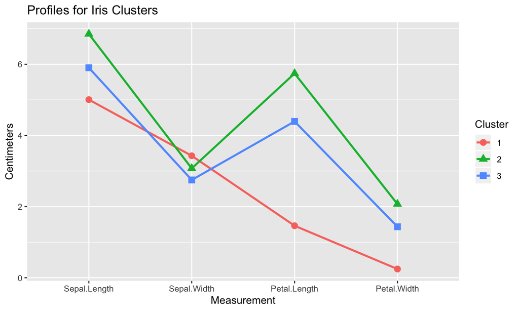

```r
library(ggplot2)
ggplot(data=dfm,
       aes(x=Measurement, y=Centimeters, group=Cluster)) +
  geom_point(size=3, aes(shape=Cluster, color=Cluster)) +
  geom_line(size=1, aes(color=Cluster)) +
  ggtitle("Profiles for Iris Clusters")
```

## Functions and Environments

### Functions

```r
f <- function(x, y, z=1){
  result <- x + (2*y) + (3*z)
  return(result)
}

f(2,3,4)
```

```
~ [1] 20
```

```r
f(2,3)
```

```
~ [1] 11
```

```r
f(x=2, y=3)
```

```
~ [1] 11
```

```r
f(z=4, y=2, 3)
```

```
~ [1] 19
```

```r
args(f)
```

```
~ function (x, y, z = 1)
~ NULL
```

### Environments

```r
x <- 5
myenv <- new.env()
assign("x", "Homer", env=myenv)
ls()
```

```
~  [1] "a"         "ages"      "b"         "cmplxNums" "dfm"
~  [6] "f"         "fit"       "libs"      "means"     "myenv"
~ [11] "names"     "passed"    "x"
```

```r
ls(myenv)
```

```
~ [1] "x"
```

```r
get("x", env=myenv)
```

```
~ [1] "Homer"
```

```r
myenv <- new.env()
myenv$x <- "Homer"
parent.env(myenv)
```

```
~ <environment: R_GlobalEnv>
```

### Function closures

```r
trim <- function(p){
  trimit <- function(x){
    n <- length(x)
    lo <- floor(n*p) + 1
    hi <- n + 1 - lo
    x <- sort.int(x, partial = unique(c(lo, hi)))[lo:hi]
  }
  trimit
}
x <- 1:10
trim10pct <- trim(.1)
y <- trim10pct(x)
y
```

```
~ [1] 2 3 4 5 6 7 8 9
```

```r
trim20pct <- trim(.2)
y <- trim20pct(x)
y
```

```
~ [1] 3 4 5 6 7 8
```

```r
ls(environment(trim10pct))
```

```
~ [1] "p"      "trimit"
```

```r
get("p", env=environment(trim10pct))
```

```
~ [1] 0.1
```

```r
makeFunction <- function(k){
  f <- function(x){
    print(x + k)
  }
}

g <- makeFunction(10)
g (4)
```

```
~ [1] 14
```

```r
k <- 2
g (5)
```

```
~ [1] 15
```

```r
ls(environment(g))
```

```
~ [1] "f" "k"
```

```r
environment(g)$k
```

```
~ [1] 10
```

### Generic functions

```r
summary(women)
```

```
~      height         weight
~  Min.   :58.0   Min.   :115.0
~  1st Qu.:61.5   1st Qu.:124.5
~  Median :65.0   Median :135.0
~  Mean   :65.0   Mean   :136.7
~  3rd Qu.:68.5   3rd Qu.:148.0
~  Max.   :72.0   Max.   :164.0
```

```r
fit <- lm(weight ~ height, data=women)
summary(fit)
```

```
~
~ Call:
~ lm(formula = weight ~ height, data = women)
~
~ Residuals:
~     Min      1Q  Median      3Q     Max
~ -1.7333 -1.1333 -0.3833  0.7417  3.1167
~
~ Coefficients:
~              Estimate Std. Error t value Pr(>|t|)
~ (Intercept) -87.51667    5.93694  -14.74 1.71e-09 ***
~ height        3.45000    0.09114   37.85 1.09e-14 ***
~ ---
~ Signif. codes:  0 '***' 0.001 '**' 0.01 '*' 0.05 '.' 0.1 ' ' 1
~
~ Residual standard error: 1.525 on 13 degrees of freedom
~ Multiple R-squared:  0.991,   Adjusted R-squared:  0.9903
~ F-statistic:  1433 on 1 and 13 DF,  p-value: 1.091e-14
```

```r
class(women)
```

```
~ [1] "data.frame"
```

```r
class(fit)
```

```
~ [1] "lm"
```

```r
methods(summary)
```

```
~  [1] summary,ANY-method
~  [2] summary,diagonalMatrix-method
~  [3] summary,sparseMatrix-method
~  [4] summary.aov
~  [5] summary.aovlist*
~  [6] summary.aspell*
~  [7] summary.check_packages_in_dir*
~  [8] summary.connection
~  [9] summary.data.frame
~ [10] summary.Date
~ [11] summary.default
~ [12] summary.ecdf*
~ [13] summary.factor
~ [14] summary.ggplot*
~ [15] summary.glm
~ [16] summary.hcl_palettes*
~ [17] summary.infl*
~ [18] summary.lm
~ [19] summary.loess*
~ [20] summary.manova
~ [21] summary.matrix
~ [22] summary.mlm*
~ [23] summary.nls*
~ [24] summary.packageStatus*
~ [25] summary.pandas.core.frame.DataFrame*
~ [26] summary.pandas.core.series.Series*
~ [27] summary.POSIXct
~ [28] summary.POSIXlt
~ [29] summary.ppr*
~ [30] summary.prcomp*
~ [31] summary.princomp*
~ [32] summary.proc_time
~ [33] summary.python.builtin.object*
~ [34] summary.rlang_error*
~ [35] summary.rlang_trace*
~ [36] summary.shingle*
~ [37] summary.srcfile
~ [38] summary.srcref
~ [39] summary.stepfun
~ [40] summary.stl*
~ [41] summary.table
~ [42] summary.trellis*
~ [43] summary.tukeysmooth*
~ [44] summary.warnings
~ see '?methods' for accessing help and source code
```

### An example of a generic function

```r
mymethod <- function(x, ...) UseMethod("mymethod")
mymethod.a <- function(x) print("Using A")
mymethod.b <- function(x) print("Using B")
mymethod.default <- function(x) print("Using Default")

x <- 1:5
y <- 6:10
z <- 10:15
class(x) <- "a"
class(y) <- "b"

mymethod(x)
```

```
~ [1] "Using A"
```

```r
mymethod(y)
```

```
~ [1] "Using B"
```

```r
mymethod(z)
```

```
~ [1] "Using Default"
```

```r
class(z) <- c("c", "a", "b")
mymethod(z)
```

```
~ [1] "Using A"
```

## The review of Control statements

- `if` statement for conditional programming
- `if...else` statement for conditional programming
- `for` loop to iterate over a fixed number of iterations
- `while` loop to iterate until a logical statement returns FALSE
- `repeat` loop to execute until told to break
- `break/next` arguments to exit and skip interations in a loop

```r
sum <- 0
repeat{
  if (sum == 6){
  print("repeat loop ends");
  break
  } else {
    sum = sum + 1
    print(paste("repeating... : ", sum, sep = ''))
  }
}
```

```
~ [1] "repeating... : 1"
~ [1] "repeating... : 2"
~ [1] "repeating... : 3"
~ [1] "repeating... : 4"
~ [1] "repeating... : 5"
~ [1] "repeating... : 6"
~ [1] "repeat loop ends"
```

## Vectorization and efficient code

```r
set.seed(1234)
mymatrix <- matrix(rnorm(1e7), ncol=10)
accum <- function(x){
  sums <- numeric(ncol(x))
  for (i in 1:ncol(x)){
    for(j in 1:nrow(x)){
      sums[i] <- sums[i] + x[j,i]
    }
  }
}
system.time(accum(mymatrix))
```

```
~    user  system elapsed
~   1.512   0.019   1.613
```

```r
system.time(colSums(mymatrix))
```

```
~    user  system elapsed
~   0.012   0.001   0.012
```

```r
set.seed(1234)
k <- 1e5
x <- rnorm(k)
y <- 0
system.time(for (i in 1:length(x)) y[i] <- x[i]^2)
```

```
~    user  system elapsed
~   0.040   0.007   0.048
```

```r
y <- numeric(k)
system.time(for (i in 1:k) y[i] <- x[i]^2)
```

```
~    user  system elapsed
~   0.013   0.000   0.014
```

```r
y <- numeric(k)
system.time(y <- x^2)
```

```
~    user  system elapsed
~   0.000   0.000   0.001
```

### From a Scalar function to the Vectorized one

```r
rep.int(x = 1:4, times = 4:1)
```

```
~  [1] 1 1 1 1 2 2 2 3 3 4
```

```r
vrep <- Vectorize(rep.int)
vrep(1:4, 4:1)
```

```
~ [[1]]
~ [1] 1 1 1 1
~
~ [[2]]
~ [1] 2 2 2
~
~ [[3]]
~ [1] 3 3
~
~ [[4]]
~ [1] 4
```

```r
vrep <- Vectorize(rep.int, "times")
vrep(times = 1:4, x = 4:1)
```

```
~ [[1]]
~ [1] 4 3 2 1
~
~ [[2]]
~ [1] 4 3 2 1 4 3 2 1
~
~ [[3]]
~  [1] 4 3 2 1 4 3 2 1 4 3 2 1
~
~ [[4]]
~  [1] 4 3 2 1 4 3 2 1 4 3 2 1 4 3 2 1
```

```r
f <- function(x = 1:3, y) c(x, y)
vf <- Vectorize(f, SIMPLIFY = FALSE)
f(1:3, 1:3)
```

```
~ [1] 1 2 3 1 2 3
```

```r
vf(1:3, 1:3)
```

```
~ [[1]]
~ [1] 1 1
~
~ [[2]]
~ [1] 2 2
~
~ [[3]]
~ [1] 3 3
```

```r
vf(y = 1:3) # Only vectorizes y, not x
```

```
~ [[1]]
~ [1] 1 2 3 1
~
~ [[2]]
~ [1] 1 2 3 2
~
~ [[3]]
~ [1] 1 2 3 3
```

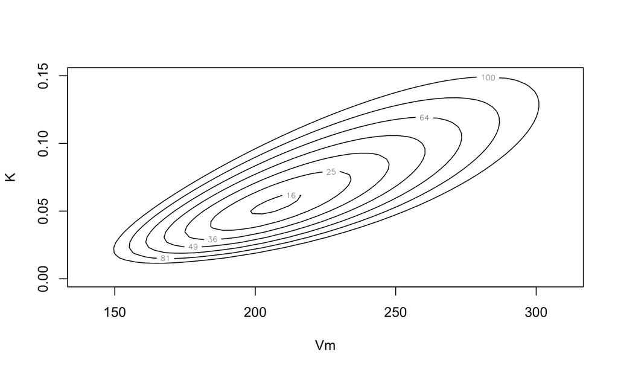

```r
# Nonlinear regression contour plot, based on nls() example
require(graphics)
SS <- function(Vm, K, resp, conc) {
    pred <- (Vm * conc)/(K + conc)
    sum((resp - pred)^2 / pred)
}
vSS <- Vectorize(SS, c("Vm", "K"))
Treated <- subset(Puromycin, state == "treated")

Vm <- seq(140, 310, length.out = 50)
K <- seq(0, 0.15, length.out = 40)
SSvals <- outer(Vm, K, vSS, Treated$rate, Treated$conc)
contour(Vm, K, SSvals, levels = (1:10)^2, xlab = "Vm", ylab = "K")
```

```r
# combn() has an argument named FUN
combnV <- Vectorize(function(x, m, FUNV = NULL) combn(x, m, FUN = FUNV),
                    vectorize.args = c("x", "m"))
combnV(4, 1:4)
```

```
~ [[1]]
~      [,1] [,2] [,3] [,4]
~ [1,]    1    2    3    4
~
~ [[2]]
~      [,1] [,2] [,3] [,4] [,5] [,6]
~ [1,]    1    1    1    2    2    3
~ [2,]    2    3    4    3    4    4
~
~ [[3]]
~      [,1] [,2] [,3] [,4]
~ [1,]    1    1    1    2
~ [2,]    2    2    3    3
~ [3,]    3    4    4    4
~
~ [[4]]
~      [,1]
~ [1,]    1
~ [2,]    2
~ [3,]    3
~ [4,]    4
```

```r
combnV(4, 1:4, function(x) sum(x))
```

```
~ [[1]]
~ [1] 1 2 3 4
~
~ [[2]]
~ [1] 3 4 5 5 6 7
~
~ [[3]]
~ [1] 6 7 8 9
~
~ [[4]]
~ [1] 10
```

## Parallelization with `foreach` and `doParallel`

The `foreach` package provides the repeated operations on multiple processors/cores on your computer, or on multiple nodes of a cluster. This enables the **parallel operations** on R.  
For more information, type `vignette('foreach')`.

The `doParallel` package is a **parallel backend** for the `foreach` package. It provides a mechanism needed to execute `foreach` loops in parallel. The user must register a parallel backend to use, otherwise `foreach` will execute tasks sequentially, even when the `%dopar%` operator is used.

```r
library(foreach)
library(doParallel)
library(rbenchmark)

cl <- makePSOCKcluster(detectCores())
registerDoParallel(cl)

eig <- function(n, p){
  x <- matrix(rnorm(n), ncol=p)
  r <- cor(x)
  eigen(r)$values
}
n <- 1e5
p <- 100
k <- 500

benchmark(justdo = {x <- foreach(i=1:k, .combine=rbind) %do% eig(n, p)},
          dopar = {x <- foreach(i=1:k, .combine=rbind) %dopar% eig(n, p)},
          replications = 1e0)
```

```
~     test replications elapsed relative user.self sys.self user.child
~ 2  dopar            1   6.698    1.000     0.314    0.040          0
~ 1 justdo            1  13.414    2.003    10.812    3.026          0
~   sys.child
~ 2         0
~ 1         0
```

### Equivalent to colMeans(m)

```r
m <- matrix(rnorm(9), 3, 3)
foreach(i=1:ncol(m), .combine=c) %do%
  mean(m[,i])
```

```
~ [1] -0.73992916  0.92349186  0.02941139
```

### Simple (and inefficient) parallel matrix multiply

```r
library(iterators)
a <- matrix(1:4, 4, 4)
b <- t(a)
foreach(b=iter(b, by='col'), .combine=cbind) %dopar%
  (a %*% b)
```

```
~      [,1] [,2] [,3] [,4]
~ [1,]    4    8   12   16
~ [2,]    8   16   24   32
~ [3,]   12   24   36   48
~ [4,]   16   32   48   64
```

### A quick sort function

```r
qsort <- function(x) {
  n <- length(x)
  if (n == 0) {
    x
  } else {
    p <- sample(n, 1)
    smaller <- foreach(y=x[-p], .combine=c) %:% when(y <= x[p]) %do% y
    larger  <- foreach(y=x[-p], .combine=c) %:% when(y >  x[p]) %do% y
    c(qsort(smaller), x[p], qsort(larger))
  }
}
qsort(runif(12))
```

```
~  [1] 0.1312442 0.2349712 0.2599108 0.2655142 0.2915500 0.2919366 0.3067929
~  [8] 0.3085538 0.3863656 0.6606622 0.7641166 0.8428095
```

```r
stopCluster(cl)
```

## Debugging

```r
args(mad)
```

```
~ function (x, center = median(x), constant = 1.4826, na.rm = FALSE,
~     low = FALSE, high = FALSE)
~ NULL
```

```r
debug(mad)
mad(1:10)
```

```
~ debugging in: mad(1:10)
~ debug: {
~     if (na.rm)
~         x <- x[!is.na(x)]
~     n <- length(x)
~     constant * if ((low || high) && n%%2 == 0) {
~         if (low && high)
~             stop("'low' and 'high' cannot be both TRUE")
~         n2 <- n%/%2 + as.integer(high)
~         sort(abs(x - center), partial = n2)[n2]
~     }
~     else median(abs(x - center))
~ }
~ debug: if (na.rm) x <- x[!is.na(x)]
~ debug: n <- length(x)
~ debug: constant * if ((low || high) && n%%2 == 0) {
~     if (low && high)
~         stop("'low' and 'high' cannot be both TRUE")
~     n2 <- n%/%2 + as.integer(high)
~     sort(abs(x - center), partial = n2)[n2]
~ } else median(abs(x - center))
~ debug: median(abs(x - center))
~ exiting from: mad(1:10)
```

```
~ [1] 3.7065
```

```r
undebug(mad)
```

### Sample debugging session with `recover()` (DIY)

```r
f <- function(x, y){
       z <- x + y
       g(z)
}
g <- function(x){
       z <- round(x)
       h(z)
}
h <- function(x){
       set.seed(1234)
       z <- rnorm(x)
       print(z)
}
options(error=recover)
f(2,3)
f(2, -3)
options(error=NULL)
```

## Profiling

`Profvis` is a tool for helping you to understand how R spends its time ;  
It provides a interactive graphical interface for visualizing data from `Rprof`, R’s built-in tool for collecting profiling data.

To make slow code faster, we need accurate information about what is making our code slow.

[output not shown]

[output not shown]

[output not shown]

[output not shown]

[output not shown]

[output not shown]

[output not shown]

[output not shown]

[interactive chart not shown]

## Rcpp

You need `Rtools` first.  
[Reference Link](http://dirk.eddelbuettel.com/papers/rcpp_sydney-rug_jul2013.pdf)

Consider the function defined as : \[f(n)=\begin{cases}n&\text{for}~~n<2\\f(n-1)+f(n-2)&\text{for}~~n\geq2\end{cases}\].

### R program

```r
f <- function(n) {
if (n < 2) return(n)
return(f(n-1) + f(n-2))
}
## Using it on first 11 arguments
sapply(0:10, f)
```

```
~  [1]  0  1  1  2  3  5  8 13 21 34 55
```

```r
require(rbenchmark)
benchmark(f(10), f(15), f(20))[,1:4]
```

```
~    test replications elapsed relative
~ 1 f(10)          100   0.009    1.000
~ 2 f(15)          100   0.142   15.778
~ 3 f(20)          100   1.388  154.222
```

### With Rcpp

```r
library(Rcpp)
cppFunction('
  int g(int n) {
    if (n < 2) return(n);
    return(g(n-1) + g(n-2));
  }
')
## Using it on first 11 arguments
sapply(0:10, g)
```

```
~  [1]  0  1  1  2  3  5  8 13 21 34 55
```

```r
benchmark(f(20), g(20), replications = 1e3)[,1:4]
```

```
~    test replications elapsed relative
~ 1 f(20)         1000  10.418  196.566
~ 2 g(20)         1000   0.053    1.000
```

```r
cppFunction('
  NumericVector logabs(NumericVector x) {
  return log(abs(x));
  }
')
logabs(seq(-5, 5, by=2))
```

```
~ [1] 1.609438 1.098612 0.000000 0.000000 1.098612 1.609438
```

### A Rcpp program.

```cpp
#include <Rcpp.h>
using namespace Rcpp;

inline double f(double x) { return ::log(::fabs(x)); }

// [[Rcpp::export]]
std::vector<double> logabs2(std::vector<double> x) {
std::transform(x.begin(), x.end(), x.begin(), f);
return x;
}
```

### You can source the program saved in `cpp` file using `sourceCpp()`.

## When you use huge data in R…

1. Use `matrix` rather than `data.frame`.
2. Use `data.table` and get used to it.
3. Always examine your program on subdata.
4. Remove temporal objects and images often. Utilitze `rm()`, `gc()`.
5. Profile your program.
6. Exploit the external compiled subroutines. For example, `Rcpp`.